# Lemon Bay Aquatic Preserve

# Oyster

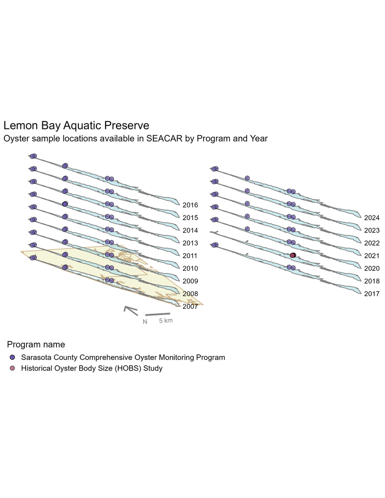

Maps showing the temporal scope of oyster sampling sites within the boundaries of *Lemon Bay Aquatic Preserve* by program name.

Click [here](https://github.com/FloridaSEACAR/SEACAR_Trend_Analyses/tree/main/Oyster/output/Oyster_temporal_scope_plots) to view spatio-temporal plots on GitHub.

## Density

For natural reefs, density decreased by an average of 29.56 oysters per square meter per year.

### Natural

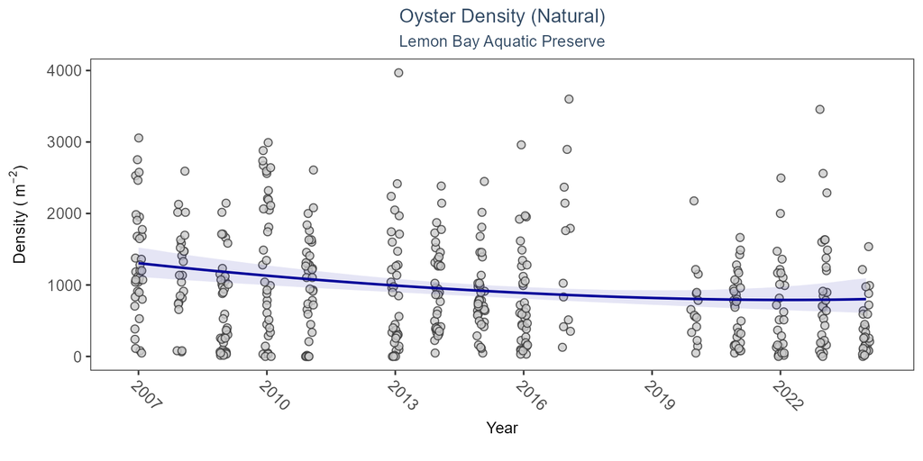

Scatter plot of oyster density over time. If the time series included five or more years with observations, an estimated trend (blue line) and a 95% credible interval (purple band) may also be plotted. Data points are jittered horizontally to reduce overlap.

Model results for Oyster Density - Natural

| Habitat Type | Shell Type | Statistical Trend | Period of Record | Estimate | Standard Error | Credible Interval |
| --- | --- | --- | --- | --- | --- | --- |
| Natural | Live Oysters | Decreasing trend | 2007 - 2024 | -29.56 | 10.41 | -49.75 to -6.83 |

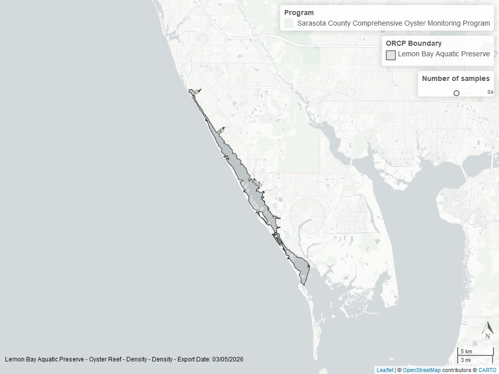

Map showing location of oyster density sampling locations within the boundaries of *Lemon Bay Aquatic Preserve*. The bubble size on the maps above reflect the amount of data available at each sampling site.

## Percent Live

For natural reefs, percent live cover showed no detectable trend between 2007 and 2024.

### Natural

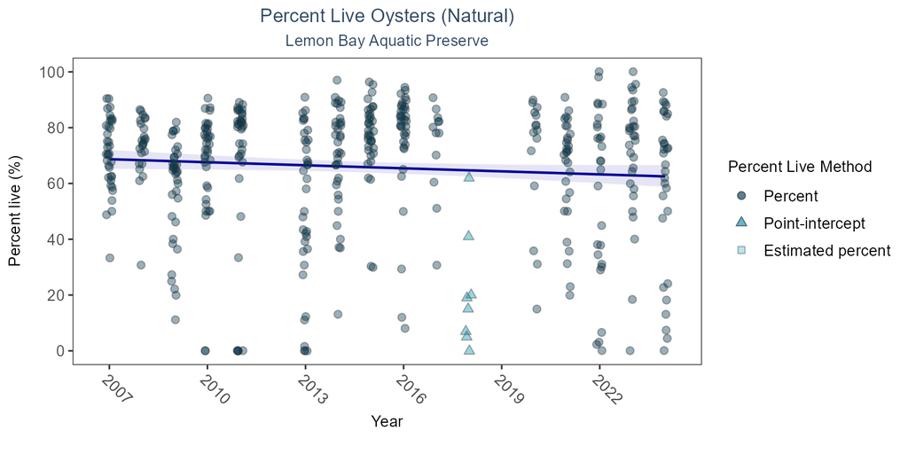

Scatter plot of percent live oysters over time. If the time series included five or more years with observations, an estimated trend (blue line) and a 95% credible interval (purple band) may also be plotted. Estimation method is represented as percent (circles), point-intercept (triangle), or estimated percent (square), with data points jittered horizontally to reduce overlap.

Model results for Oyster Percent Live - Natural

| Habitat Type | Shell Type | Statistical Trend | Period of Record | Estimate | Standard Error | Credible Interval |
| --- | --- | --- | --- | --- | --- | --- |
| Natural | Live Oysters | No detectable trend | 2007 - 2024 | -0.36 | 0.19 | -0.71 to 0.01 |

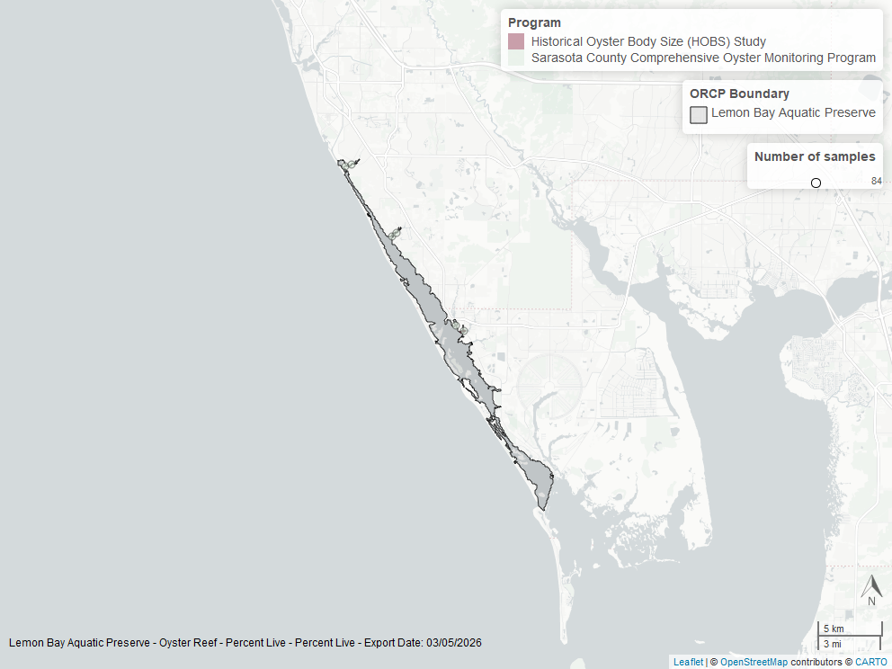

Map showing location of oyster percent live sampling locations within the boundaries of *Lemon Bay Aquatic Preserve*. The bubble size on the maps above reflect the amount of data available at each sampling site.

## Shell Height

For natural reefs, there was insufficient data to calculate a trend for live oysters in the 25-75mm size class. Models are not run on dead oyster shell measurements.

### Natural

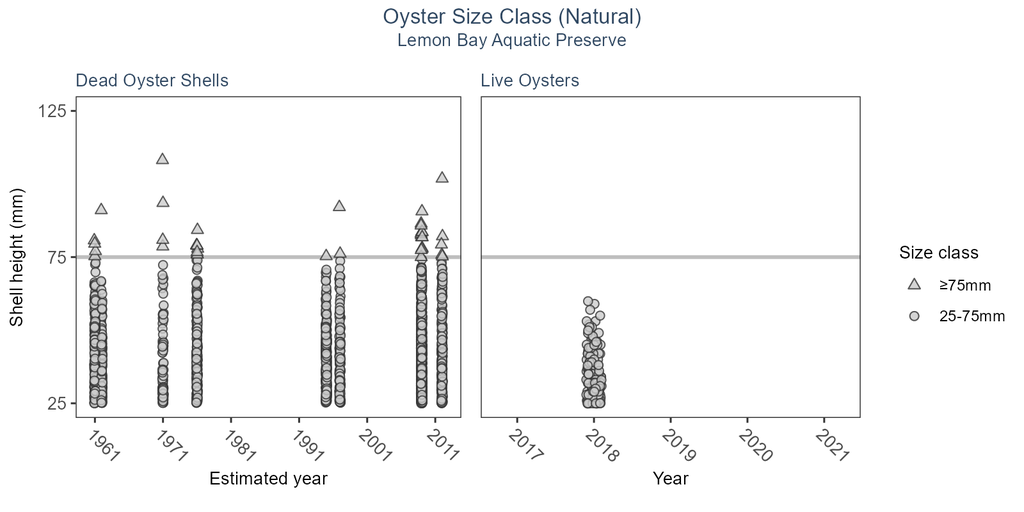

Model results for Oyster Shell Height - Natural

| Habitat Type | Shell Type | SizeClass | Statistical Trend | Period of Record | No. of Samples | Estimate | Standard Error | Credible Interval |
| --- | --- | --- | --- | --- | --- | --- | --- | --- |
| Natural | Dead Oyster Shells | >75mm | Model not run on dead oyster shell | 1961 - 2012 | 38 | - | - | - |
| Natural | Dead Oyster Shells | 25-75mm | Model not run on dead oyster shell | 1961 - 2012 | 2029 | - | - | - |
| Natural | Live Oysters | 25-75mm | Insufficient data | 2018 - 2018 | 152 | - | - | - |

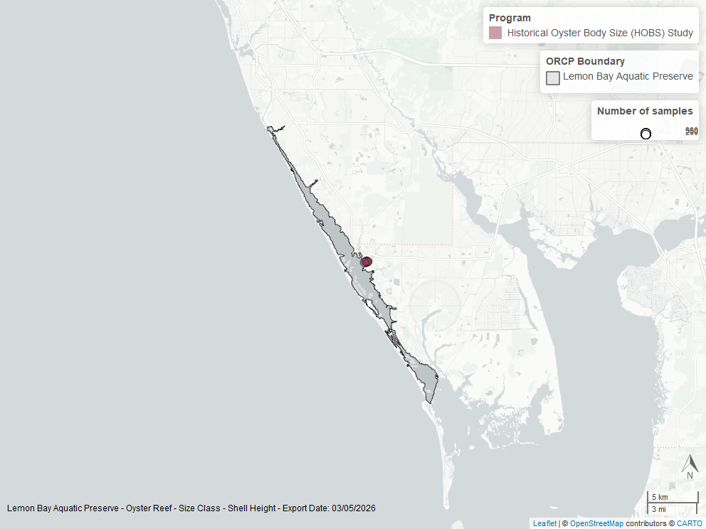

Map showing location of oyster shell height sampling locations within the boundaries of *Lemon Bay Aquatic Preserve*. The bubble size on the maps above reflect the amount of data available at each sampling site.

# Species list

| Acanthostracion quadricornis<sup>2</sup> | Eucinostomus gula<sup>2</sup> | Ocyurus chrysurus<sup>2</sup> |
| --- | --- | --- |
| Achirus lineatus<sup>2</sup> | Eucinostomus harengulus<sup>2</sup> | Ogcocephalus cubifrons<sup>2</sup> |
| Albula spp.<sup>2</sup> | Eucinostomus spp.<sup>2</sup> | Ogcocephalus spp.<sup>2</sup> |
| Aluterus schoepfii<sup>2</sup> | Eugerres plumieri<sup>2</sup> | Oligoplites saurus<sup>2</sup> |
| Anarchopterus criniger<sup>2</sup> | Fistularia tabacaria<sup>2</sup> | Opisthonema oglinum<sup>2</sup> |
| Anchoa hepsetus<sup>2</sup> | Fundulus similis<sup>2</sup> | Opsanus beta<sup>2</sup> |
| Anchoa mitchilli<sup>2</sup> | Gobiesox strumosus<sup>2</sup> | Orthopristis chrysoptera<sup>2</sup> |
| Anchoa spp.<sup>2</sup> | Gobiosoma longipala<sup>2</sup> | Paralichthys albigutta<sup>2</sup> |
| Ancylopsetta quadrocellata<sup>2</sup> | Gobiosoma robustum<sup>2</sup> | Penaeus duorarum<sup>2</sup> |
| Archosargus probatocephalus<sup>2</sup> | Gobiosoma spp.<sup>2</sup> | Penicillus capitatus<sup>1</sup> |
| Ariopsis felis<sup>2</sup> | Haemulon plumierii<sup>2</sup> | Pogonias cromis<sup>2</sup> |
| Bagre marinus<sup>2</sup> | Halodule wrightii<sup>1</sup> | Prionotus rubio<sup>2</sup> |
| Bairdiella chrysoura<sup>2</sup> | Halophila engelmannii<sup>1</sup> | Prionotus scitulus<sup>2</sup> |
| Bathygobius soporator<sup>2</sup> | Harengula jaguana<sup>2</sup> | Prionotus tribulus<sup>2</sup> |
| Brevoortia spp.<sup>2</sup> | Hemiramphus brasiliensis<sup>2</sup> | Sciaenops ocellatus<sup>2</sup> |
| Calamus penna<sup>2</sup> | Hippocampus erectus<sup>2</sup> | Scomberomorus maculatus<sup>2</sup> |
| Callinectes sapidus<sup>2</sup> | Hippocampus zosterae<sup>2</sup> | Scorpaena brasiliensis<sup>2</sup> |
| Caranx hippos<sup>2</sup> | Hypleurochilus caudovittatus<sup>2</sup> | Selene vomer<sup>2</sup> |
| Caranx latus<sup>2</sup> | Hyporhamphus meeki<sup>2</sup> | Serraniculus pumilio<sup>2</sup> |
| Caulerpa mexicana<sup>1</sup> | Hyporhamphus unifasciatus<sup>2</sup> | Serranus subligarius<sup>2</sup> |
| Caulerpa prolifera<sup>1</sup> | Hypsoblennius hentz<sup>2</sup> | Sphoeroides nephelus<sup>2</sup> |
| Caulerpa sertularioides<sup>1</sup> | Lachnolaimus maximus<sup>2</sup> | Sphoeroides spengleri<sup>2</sup> |
| Caulerpa spp.<sup>1</sup> | Lagodon rhomboides<sup>2</sup> | Sphyraena barracuda<sup>2</sup> |
| Centropomus undecimalis<sup>2</sup> | Leiostomus xanthurus<sup>2</sup> | Strongylura marina<sup>2</sup> |
| Centropristis striata<sup>2</sup> | Limulus polyphemus | Strongylura notata<sup>2</sup> |
| Chaetodipterus faber<sup>2</sup> | Lucania parva<sup>2</sup> | Symphurus plagiusa<sup>2</sup> |
| Chasmodes saburrae<sup>2</sup> | Lutjanus analis<sup>2</sup> | Syngnathus floridae<sup>2</sup> |
| Chilomycterus schoepfii<sup>2</sup> | Lutjanus griseus<sup>2</sup> | Syngnathus louisianae<sup>2</sup> |
| Chloroscombrus chrysurus<sup>2</sup> | Lutjanus synagris<sup>2</sup> | Syngnathus scovelli<sup>2</sup> |
| Citharichthys macrops<sup>2</sup> | Menippe spp.<sup>2</sup> | Syngnathus springeri<sup>2</sup> |
| Cynoscion arenarius<sup>2</sup> | Menticirrhus americanus<sup>2</sup> | Synodus foetens<sup>2</sup> |
| Cynoscion nebulosus<sup>2</sup> | Menticirrhus saxatilis<sup>2</sup> | Syringodium filiforme<sup>1</sup> |
| Diapterus auratus<sup>2</sup> | Microgobius gulosus<sup>2</sup> | Thalassia testudinum<sup>1</sup> |
| Diodon holocanthus<sup>2</sup> | Monacanthus ciliatus<sup>2</sup> | Total seagrass<sup>1</sup> |
| Diplectrum formosum<sup>2</sup> | Mugil cephalus<sup>2</sup> | Trachinotus carolinus<sup>2</sup> |
| Diplodus holbrookii<sup>2</sup> | Mugil curema<sup>2</sup> | Trachinotus falcatus<sup>2</sup> |
| Drift algae<sup>1</sup> | Mugil trichodon<sup>2</sup> | Trinectes maculatus<sup>2</sup> |
| Elops saurus<sup>2</sup> | Mycteroperca bonaci<sup>2</sup> | Tylosurus crocodilus<sup>2</sup> |
| Epinephelus itajara<sup>2</sup> | Mycteroperca microlepis<sup>2</sup> | Urophycis floridana<sup>2</sup> |
| Epinephelus morio<sup>2</sup> | Nicholsina usta<sup>2</sup> | Acanthostracion quadricornis<sup>2</sup> |
| Etropus crossotus<sup>2</sup> | No grass in quadrat<sup>1</sup> | Achirus lineatus<sup>2</sup> |

1 - Submerged Aquatic Vegetation, 2 - Nekton

# References

1.

Florida Department of Environmental Protection (DEP); Office of Resilience and Coastal Protection (RCP); Charlotte Harbor Aquatic Preserves. [Charlotte Harbor Estuaries Volunteer Water Quality Monitoring Network](https://data.florida-seacar.org/programs/details/476). (2024).

2.

Florida Department of Environmental Protection (DEP). [Florida STORET / WIN](https://data.florida-seacar.org/programs/details/5002). (2024).

3.

Charlotte Harbor National Estuary Program (CHNEP). [Coastal Charlotte Harbor Monitoring Network](https://data.florida-seacar.org/programs/details/513). (2024).

4.

U.S. Environmental Protection Agency (EPA). [EPA STOrage and RETrieval Data Warehouse (STORET)/WQX](https://data.florida-seacar.org/programs/details/103). (2023).

5.

U.S. Environmental Protection Agency (EPA); Office of Water; National Oceanic and Atmospheric Administration (NOAA); U.S. Geological Survey (USGS); U.S. Fish and Wildlife Service (USFWS); National Estuary Program (NEP); coastal states. [National Aquatic Resource Surveys, National Coastal Condition Assessment](https://data.florida-seacar.org/programs/details/118). (2021).

6.

Florida Fish and Wildlife Conservation Commission (FWC). [Fisheries-Independent Monitoring (FIM) Program](https://data.florida-seacar.org/programs/details/69). (2022).

7.

Southwest Florida Water Management District (SWFWMD). [Southwest Florida Water Management District - Water Quality Monitoring](https://data.florida-seacar.org/programs/details/479). (2024).

8.

Florida Fish and Wildlife Conservation Commission (FWC); Florida Fish and Wildlife Research Institute (FWRI). [Harmful Algal Bloom Marine Observation Network](https://data.florida-seacar.org/programs/details/95). (2018).

9.

Sarasota County (Florida). [Sarasota County Seagrass Monitoring](https://data.florida-seacar.org/programs/details/568). (2023).

10.

Florida Department of Environmental Protection (DEP); Office of Resilience and Coastal Protection (RCP); Charlotte Harbor Aquatic Preserves. [Charlotte Harbor Seagrass Monitoring](https://data.florida-seacar.org/programs/details/570). (2023).